# Exploratory Data Analysis: Red Wine Quality

Udacity Data Analyst Nanodegree: Project 4

Author: Ke Zhang

Submission Date: 2017-04-04 (Revision 1)

# Abstract

This project performs an exploratory data analysis on the chemical properties influencing the quality of red wines.

- Link to the red wine quality data set: [**wineQualityReds.csv**](https://s3.amazonaws.com/udacity-hosted-downloads/ud651/wineQualityReds.csv)
- Link to the data set description: [**wineQualityInfo.txt**](https://s3.amazonaws.com/udacity-hosted-downloads/ud651/wineQualityInfo.txt)

# Prepare and Preview Data

In this secion we will load the red wine data set and display the structure and some basic statistics of the variables.

```
## 'data.frame':    1599 obs. of  13 variables:
##  $ X                   : int  1 2 3 4 5 6 7 8 9 10 ...
##  $ fixed.acidity       : num  7.4 7.8 7.8 11.2 7.4 7.4 7.9 7.3 7.8 7.5 ...
##  $ volatile.acidity    : num  0.7 0.88 0.76 0.28 0.7 0.66 0.6 0.65 0.58 0.5 ...
##  $ citric.acid         : num  0 0 0.04 0.56 0 0 0.06 0 0.02 0.36 ...
##  $ residual.sugar      : num  1.9 2.6 2.3 1.9 1.9 1.8 1.6 1.2 2 6.1 ...
##  $ chlorides           : num  0.076 0.098 0.092 0.075 0.076 0.075 0.069 0.065 0.073 0.071 ...
##  $ free.sulfur.dioxide : num  11 25 15 17 11 13 15 15 9 17 ...
##  $ total.sulfur.dioxide: num  34 67 54 60 34 40 59 21 18 102 ...
##  $ density             : num  0.998 0.997 0.997 0.998 0.998 ...
##  $ pH                  : num  3.51 3.2 3.26 3.16 3.51 3.51 3.3 3.39 3.36 3.35 ...
##  $ sulphates           : num  0.56 0.68 0.65 0.58 0.56 0.56 0.46 0.47 0.57 0.8 ...
##  $ alcohol             : num  9.4 9.8 9.8 9.8 9.4 9.4 9.4 10 9.5 10.5 ...
##  $ quality             : int  5 5 5 6 5 5 5 7 7 5 ...
```

Structure of the data:

- There are **13** numeric variables with in total **1599** observations.
- The variable *X* is the identifier column which can be ignored in the following analysis.
- According to the description the variable *quality* has a value range between **0** (very bad) and **10** (very excellent). In this data set there are mainly **5** and **6** ratings.

We’ll drop *X* since it is not useful for our analysis.

Now let’s display some basic statistics:

```
##  fixed.acidity   volatile.acidity  citric.acid    residual.sugar
##  Min.   : 4.60   Min.   :0.1200   Min.   :0.000   Min.   : 0.900
##  1st Qu.: 7.10   1st Qu.:0.3900   1st Qu.:0.090   1st Qu.: 1.900
##  Median : 7.90   Median :0.5200   Median :0.260   Median : 2.200
##  Mean   : 8.32   Mean   :0.5278   Mean   :0.271   Mean   : 2.539
##  3rd Qu.: 9.20   3rd Qu.:0.6400   3rd Qu.:0.420   3rd Qu.: 2.600
##  Max.   :15.90   Max.   :1.5800   Max.   :1.000   Max.   :15.500
##    chlorides       free.sulfur.dioxide total.sulfur.dioxide
##  Min.   :0.01200   Min.   : 1.00       Min.   :  6.00
##  1st Qu.:0.07000   1st Qu.: 7.00       1st Qu.: 22.00
##  Median :0.07900   Median :14.00       Median : 38.00
##  Mean   :0.08747   Mean   :15.87       Mean   : 46.47
##  3rd Qu.:0.09000   3rd Qu.:21.00       3rd Qu.: 62.00
##  Max.   :0.61100   Max.   :72.00       Max.   :289.00
##     density             pH          sulphates         alcohol
##  Min.   :0.9901   Min.   :2.740   Min.   :0.3300   Min.   : 8.40
##  1st Qu.:0.9956   1st Qu.:3.210   1st Qu.:0.5500   1st Qu.: 9.50
##  Median :0.9968   Median :3.310   Median :0.6200   Median :10.20
##  Mean   :0.9967   Mean   :3.311   Mean   :0.6581   Mean   :10.42
##  3rd Qu.:0.9978   3rd Qu.:3.400   3rd Qu.:0.7300   3rd Qu.:11.10
##  Max.   :1.0037   Max.   :4.010   Max.   :2.0000   Max.   :14.90
##     quality
##  Min.   :3.000
##  1st Qu.:5.000
##  Median :6.000
##  Mean   :5.636
##  3rd Qu.:6.000
##  Max.   :8.000
```

Summary of basic statistics:

- The *X* index column is now removed.
- The output above shows the basic statistics of the remaining **12** variables.
- Quality in this data set has a value ranging from **3** to **8** with a mean value of **5.6** and a median of **6.0**.
- The five features *residual sugar*, *chlorides*, *free sulfur dioxide*, *total sulfur dioxide* and *sulphates* have extreme large maximum values compared to their mean and median values.
- In the lower end the attribute *citric acid* contains zeros.

We are now interested how many zeros are in *citric acid*:

```
## [1] 132
```

- Citric Acid contains as much as 132 zero values. The documentation says that the citric acid is found in small quantities in wines. So it should be fine with these zeros.

# Univariate Plots Section

### Central tendencies and outliers

In the first visualization we want to draw some *boxplots* to reveal the central tendencies and dispersion of our numerical attributes and may also indicate some outliers:

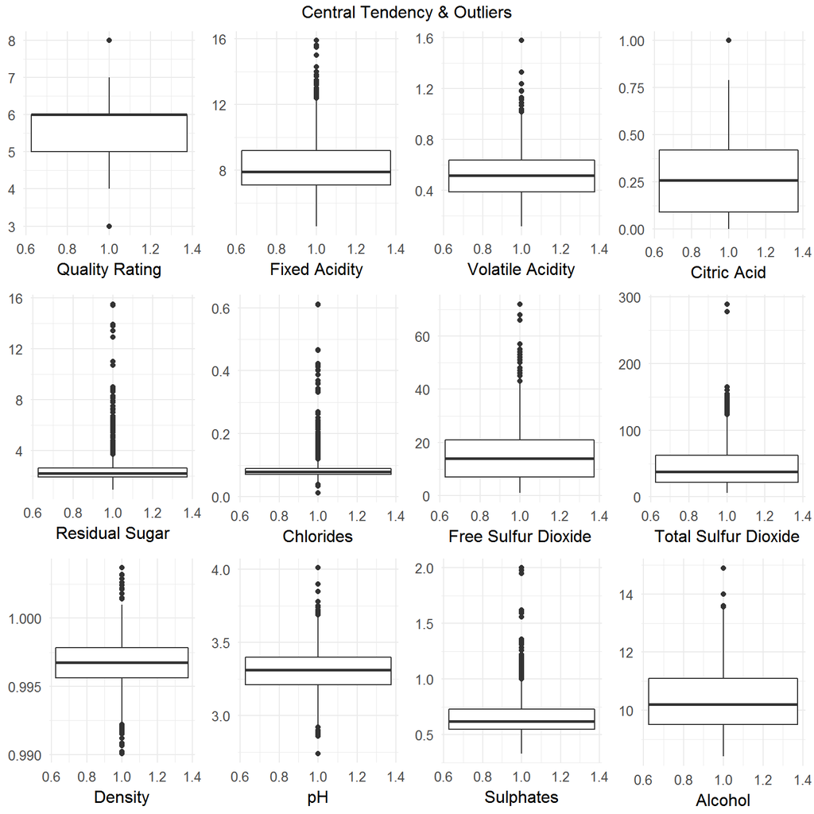

- As we saw previously in the basic statistics the five features *residual sugar*, *chlorides*, *free sulfur dioxide*, *total sulfur dioxide*, *sulphates* have extreme large outliers which we want to remove in the next step.

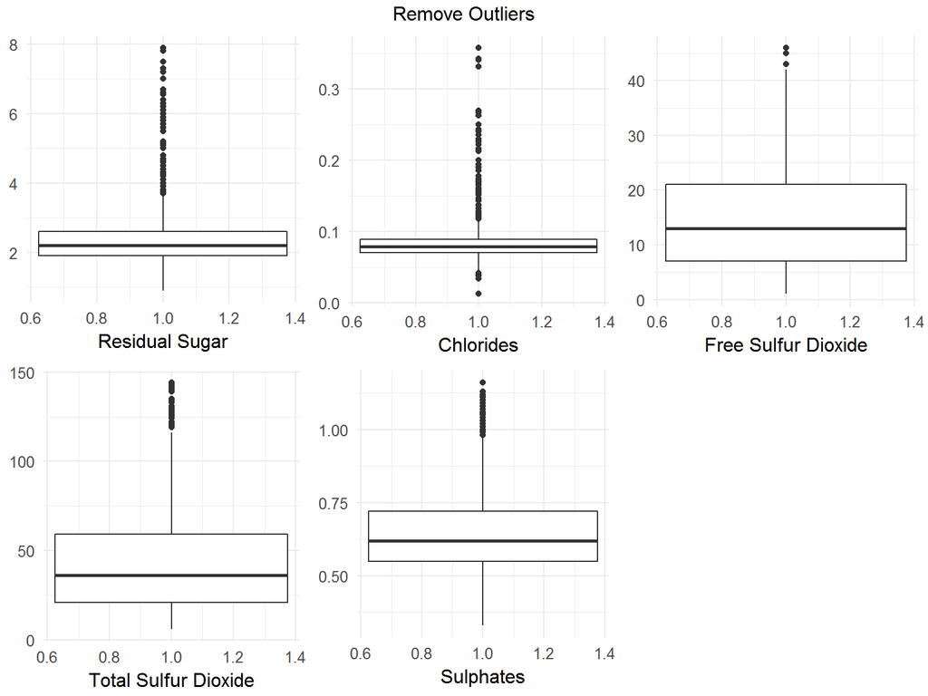

```
##  fixed.acidity    volatile.acidity  citric.acid     residual.sugar
##  Min.   : 4.600   Min.   :0.1200   Min.   :0.0000   Min.   :0.900
##  1st Qu.: 7.100   1st Qu.:0.3900   1st Qu.:0.0900   1st Qu.:1.900
##  Median : 7.900   Median :0.5200   Median :0.2500   Median :2.200
##  Mean   : 8.322   Mean   :0.5272   Mean   :0.2659   Mean   :2.415
##  3rd Qu.: 9.200   3rd Qu.:0.6400   3rd Qu.:0.4200   3rd Qu.:2.600
##  Max.   :15.900   Max.   :1.5800   Max.   :0.7900   Max.   :7.900
##    chlorides       free.sulfur.dioxide total.sulfur.dioxide
##  Min.   :0.01200   Min.   : 1.00       Min.   :  6.00
##  1st Qu.:0.07000   1st Qu.: 7.00       1st Qu.: 21.00
##  Median :0.07900   Median :13.00       Median : 36.00
##  Mean   :0.08292   Mean   :15.07       Mean   : 43.79
##  3rd Qu.:0.08900   3rd Qu.:21.00       3rd Qu.: 59.00
##  Max.   :0.35800   Max.   :46.00       Max.   :144.00
##     density             pH          sulphates         alcohol
##  Min.   :0.9901   Min.   :2.860   Min.   :0.3300   Min.   : 8.40
##  1st Qu.:0.9956   1st Qu.:3.220   1st Qu.:0.5500   1st Qu.: 9.50
##  Median :0.9967   Median :3.320   Median :0.6200   Median :10.20
##  Mean   :0.9967   Mean   :3.318   Mean   :0.6435   Mean   :10.45
##  3rd Qu.:0.9978   3rd Qu.:3.400   3rd Qu.:0.7200   3rd Qu.:11.10
##  Max.   :1.0032   Max.   :4.010   Max.   :1.1600   Max.   :14.90
##     quality
##  Min.   :3.000
##  1st Qu.:5.000
##  Median :6.000
##  Mean   :5.646
##  3rd Qu.:6.000
##  Max.   :8.000
```

- The top 1% extreme large values are now removed from the variables *residual sugar*, *chlorides*, *free sulfur dioxide*, *total sulfur dioxide*, and *sulphates*.

### Frequency distributions of the variables

In the next plot we want to analyze the frequency distributions of the variables using histograms:

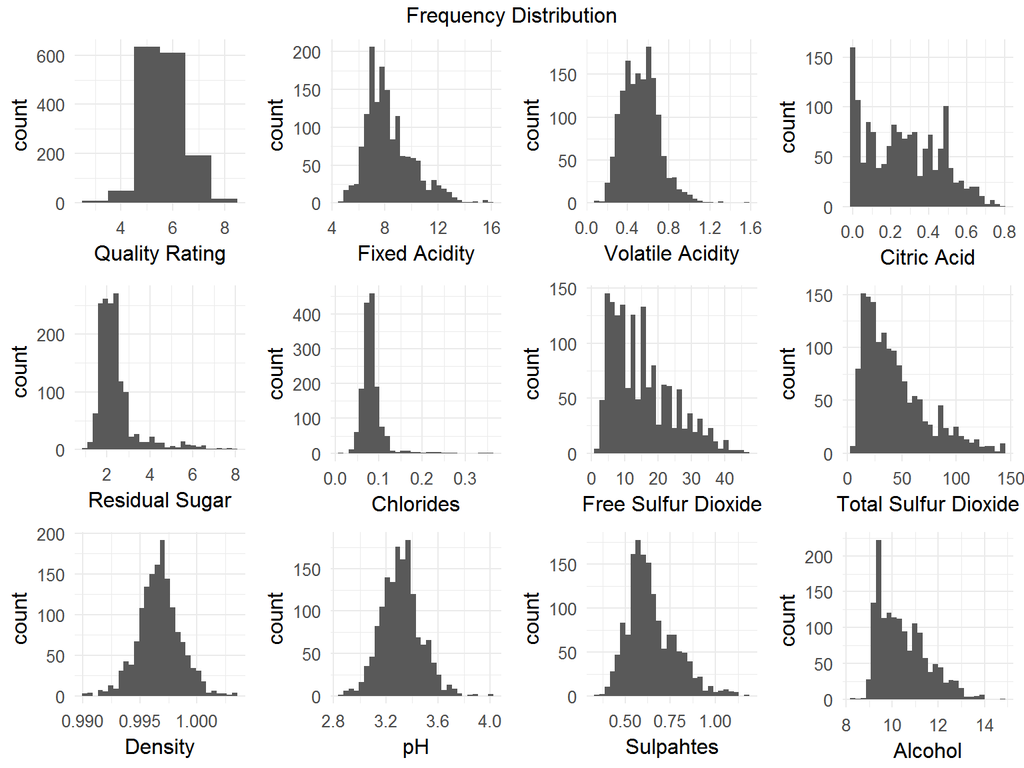

In the historgram grid above we can summarize:

- The variable *density* and *pH* have nearly normal curves with a few outliers.
- The other variables *fixed acidity*, *total sulfur dioxide*, *free sulfur dioxide* and *sulphates* are more or less right skewed and long tailed.
- *Quality* is slightly left skewed.

We have learnt that some right skewed variables.

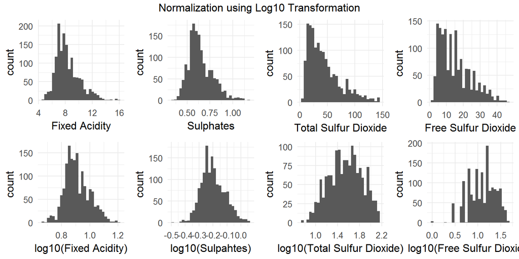

- After log10 transformation the variables *fixed.acidity*, *sulphates*, *total sulfur dioxide* and *free sulfur dioxide* are now more or less nearly normal.

### Create quality levels

Since the most common quality ratings are 5 or 6 and the other ratings have far less data points. We create here a new ordered *rating* variable for more proper analysis:

- `[0-4]`: bad
- `[5-6]`: average
- `[7-10]`: excellent

```
##       bad   average excellent
##        61      1243       211
```

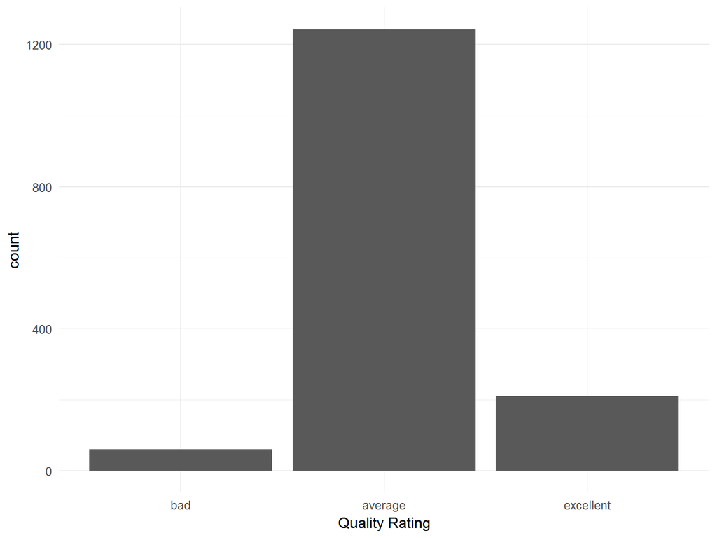

After the grouping into three categories it appears that most of the red wines are of average quality, followed by excellent, and then bad. Since there are so many average wines the question would be what makes a wine excellent or bad. We will address this issue in the bivariate and multivariate analysis.

# Univariate Analysis

### What is the structure of your dataset?

In the data set there are 1599 observations about the variants of the Portuguese “Vinho Verde” wine and 12 variables about each wine. After the data cleaning phase 84 outliers were removed what leave us 1515 observations left. (Note: The top 1% of outliers were removed from the variables *residual sugar*, *chlorides*, *free sulfur dioxide*, *total sulfur dioxide* and sulphates.)

Additional to better understand the differences between excellent and bad wines we created an extra ordered variable called *rating* which summaries the numeric *quality* values into the three categories: bad, average and excellent.

Let’s recheck the data structure:

```
## 'data.frame':    1515 obs. of  13 variables:
##  $ fixed.acidity       : num  7.4 7.8 7.8 11.2 7.4 7.4 7.9 7.3 7.8 7.5 ...
##  $ volatile.acidity    : num  0.7 0.88 0.76 0.28 0.7 0.66 0.6 0.65 0.58 0.5 ...
##  $ citric.acid         : num  0 0 0.04 0.56 0 0 0.06 0 0.02 0.36 ...
##  $ residual.sugar      : num  1.9 2.6 2.3 1.9 1.9 1.8 1.6 1.2 2 6.1 ...
##  $ chlorides           : num  0.076 0.098 0.092 0.075 0.076 0.075 0.069 0.065 0.073 0.071 ...
##  $ free.sulfur.dioxide : num  11 25 15 17 11 13 15 15 9 17 ...
##  $ total.sulfur.dioxide: num  34 67 54 60 34 40 59 21 18 102 ...
##  $ density             : num  0.998 0.997 0.997 0.998 0.998 ...
##  $ pH                  : num  3.51 3.2 3.26 3.16 3.51 3.51 3.3 3.39 3.36 3.35 ...
##  $ sulphates           : num  0.56 0.68 0.65 0.58 0.56 0.56 0.46 0.47 0.57 0.8 ...
##  $ alcohol             : num  9.4 9.8 9.8 9.8 9.4 9.4 9.4 10 9.5 10.5 ...
##  $ quality             : int  5 5 5 6 5 5 5 7 7 5 ...
##  $ rating              : Ord.factor w/ 3 levels "bad"<"average"<..: 2 2 2 2 2 2 2 3 3 2 ...
```

### What is/are the main feature(s) of interest in your dataset?

Our main goal is to determine what makes a wine taste bad or excellent. So the *quality* (or *rating*) is the main feature and the dependent variable. The other 11 attributes are independent variables.

### What other features in the dataset do you think will help support your investigation into your feature(s) of interest?

I suspect alcohol, residual sugar and pH value could play a key role in the quality. In my opinion these are the factors which may make wine taste different.

The pearson’s correlation may give us a more precise answer. The correlations below are from the independent variables and the *quality* value. The table identifies *alcohol*, *volatile.acidity* and *sulphates* as the top 3 attributes having the strongest linear correlations with quality.

```
##              alcohol     volatile.acidity            sulphates
##                 0.47                 0.39                 0.38
##          citric.acid total.sulfur.dioxide              density
##                 0.24                 0.20                 0.17
##        fixed.acidity            chlorides                   pH
##                 0.12                 0.12                 0.08
##  free.sulfur.dioxide       residual.sugar
##                 0.04                 0.02
```

### Did you create any new variables from existing variables in the dataset?

- I created an ordered rating variable which is a subset of quality based on three distinct categories: bad: `[0,4]`, average: `[5,6]` and excellent: `[7,10]`
- The index variable X was removed because it was not used in the analysis.

### Of the features you investigated, were there any unusual distributions?

Did you perform any operations on the data to tidy, adjust, or change the form  
of the data? If so, why did you do this?

# Bivariate Plots Section

### Correlation Matrix combined with significance test:

Pearson’s correlation matrix is a good indicator for linear relationships. Let’s examine which variables are correlated with each other:

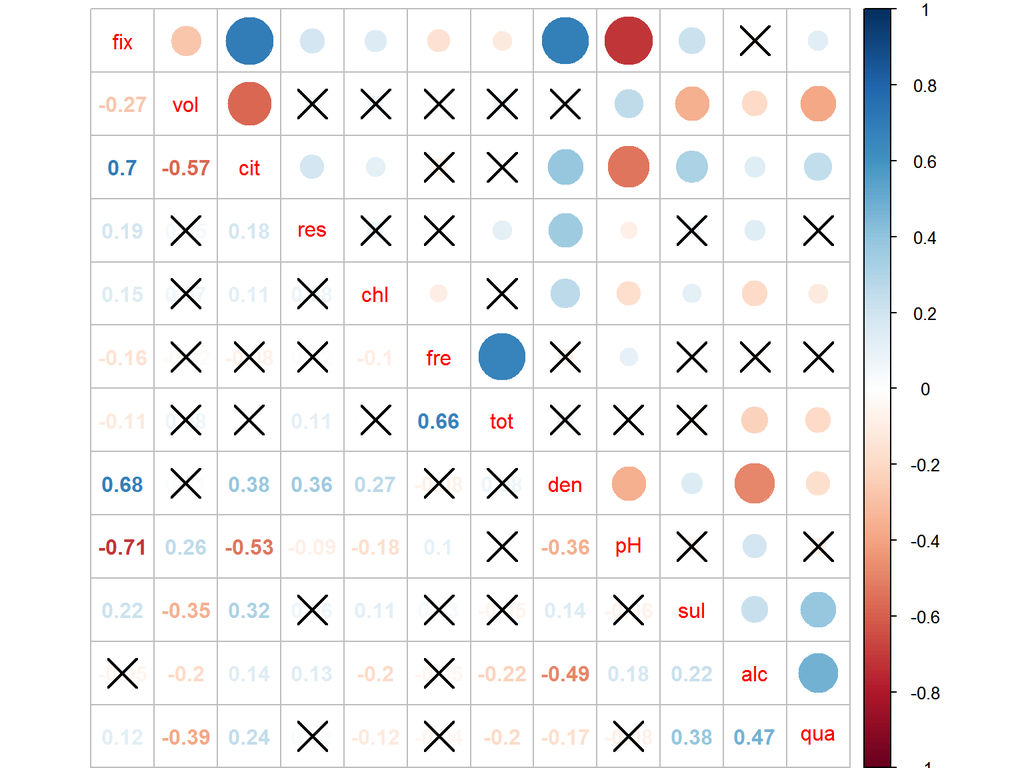

- Additional to the correlation heatmap and numbers we crossed the insignificant relationships using *corr.test()*, p=0.001 and 95% confidence interval.
- The attribute names are abbreviated to fit into the matrix, e.g. *fix* for ‘fixed acidity’.
- The variables *alcohol*, *citric acid* and *sulphates* are positively correlated to *quality* and tend to increase as the *quality* rating gets higher.
- The variables *volatile acidity*, *total sulfur dioxide*, *density*, *chlorides* are negative correlated to quality.
- The above dependency test shows also that the *quality* rating is not linear correlated with the variables *residual sugar*, *free sulfur dioxide* and *pH*.
  - The correlation between *quality* and *pH* or *free sulfur dioxide* are only marginal.
  - *Residual sugar* does not vary with *quality*.
- The matrix plot identifies several moderate to strong correlations (abs(corr) >= 0.5) between the independent variables. The one with stronger correlation to *quality* is bolded:
  - *fixed acidity* and *citric acid*
  - *fixed acidity* and *density*
  - *fixed acidity* and *pH*
  - *volatile acidity* and *citric acid*
  - *citric acid* and *pH*
  - *alcohol* and *density*
  - *free sulfur dioxide* and *total sulfur dioxide*
- In the following analysis we may prefer to use the attributes having stronger correlation with quality (marked as bold). The **top 5** independent variables ordered by absolute correlation and substitutability:
  - *alcohol*
  - *volatile acidity*
  - *sulphates*
  - *total sulfur dioxide*
  - *chlorides*

### Relationship between *quality* and the other independent variables

In the following we use side-by-side box plots to show the relationship between quality and the other independent variables and the differences in the independent variable across levels of quality.

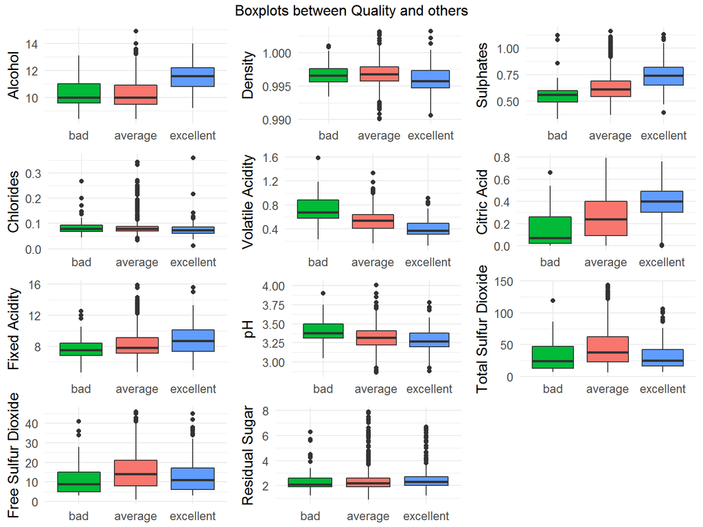

From the side-by-side boxplots certain tendencies can be recognized:

- Excellent wines tend to have:
  - higher *alcohol*
  - lower *density*
  - lower *volatile acidity* and *pH*
  - higher *citric acid* and *fixed acidity*
  - higher *sulphates*
- Bad wines tend to have:
  - lower *sulphates*
  - higher *volatile acidity* and *pH*
  - lower *citric acid* and *fixed acidity*
- Average wines tend to have:
  - higher *total sulfur dioxide* and *free sulfur dioxide*

Let’s save some combinations for the multivariate analysis:

- *alcohol* and *sulphates* to identify excellent wines
  - higher *alcohol*
  - higher *sulphates*
- *total sulfur dioxide* and *sulphates* to identify average wines
  - higher *total sulfur dioxide*
  - average *sulphates*
- *volatile acidity* and *sulphates* to identify bad wines
  - higher *volatile acidity*
  - lower *sulphates*

### Analysis using conditional density plot

In the next step we want to analyze some of favored features so far using the conditional density plots.

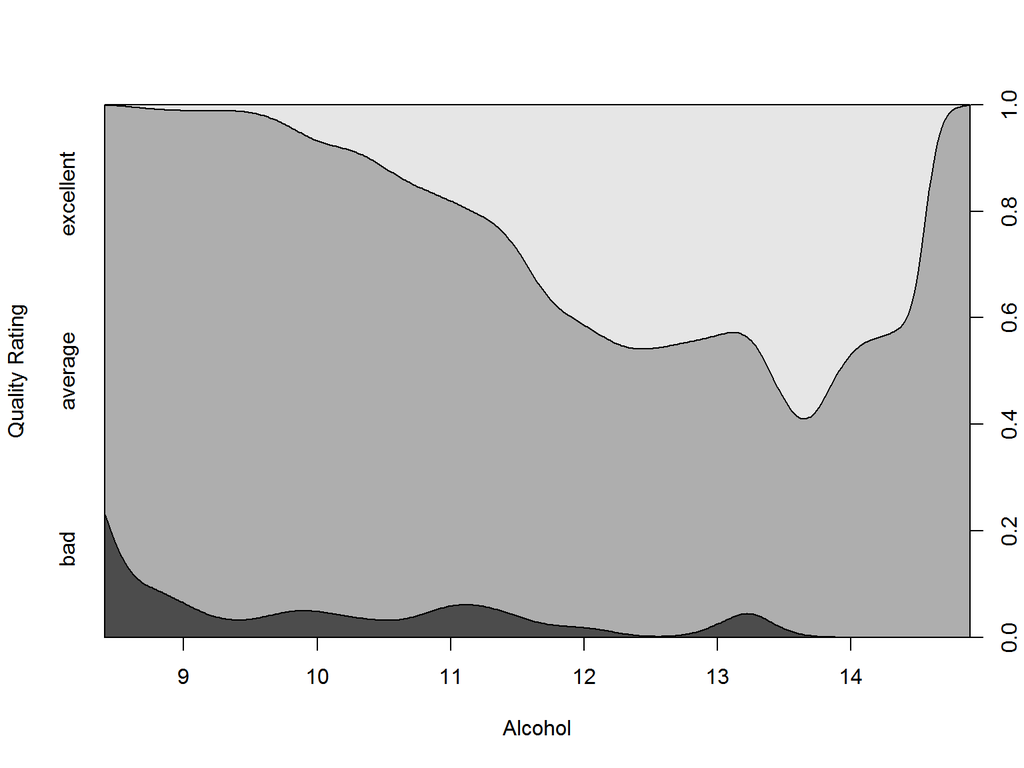

Conditional density function between *alcohol* and *quality*:

- Excellent wines have an alcohol content between 9 and 15.
- The probability of being excellent increases with the alcohol content when the alcohol is below 13.5%.
- Lower alcohol content tends to have more chance being bad.

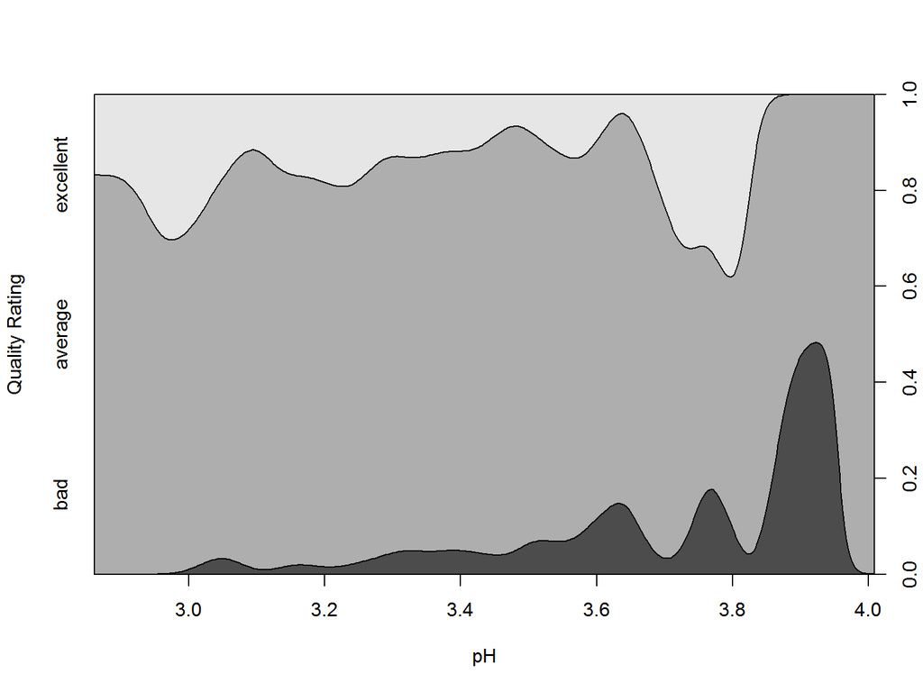

Conditional density function between *pH* and *quality*:

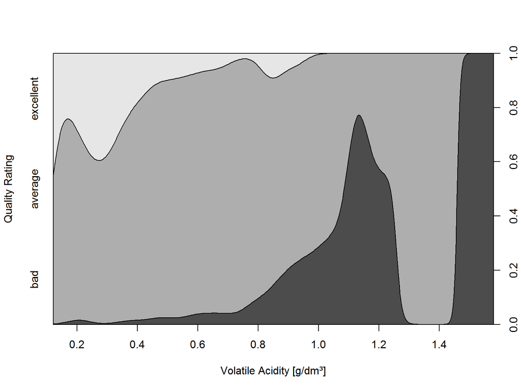

Conditional density function between *volatile acidity* and *quality*:

- An excellent wine quality has a volatile acidity between 0 to 1.0.
- A volatile acidity above 1.5 is always bad.
- The probabily of being execellent is at the greatest when volatile acidity is below 0.35(~30%)
- When volatile acidity is below 0.7 the wine quality is nearly always good or excellent.
- A volatile acidity near 1.1 is also a bad indicator for good wines.

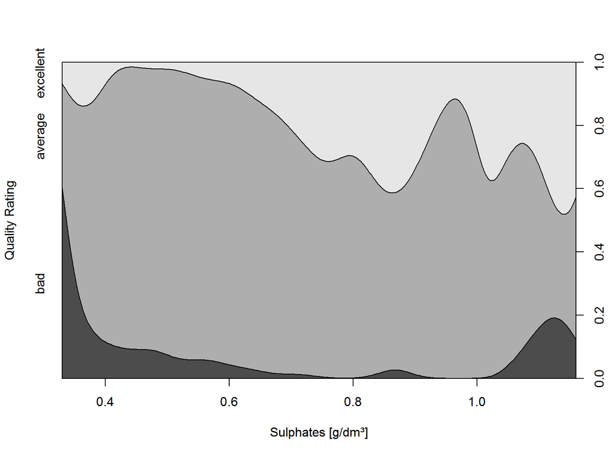

Conditional density function between *sulphates* and *quality*:

# Bivariate Analysis

### Talk about some of the relationships you observed in this part of the investigation. How did the feature(s) of interest vary with other features in the dataset?

From the correlation matrix and the boxplots, it appears that *alcohol*, *volatile acidity*, *density*, *chlorides* and *sulphates* tend to change as the quality of wine gets higher.

Higher *alcohol*, *sulphates* and *citric acid* combined with lower *volatile acidity* and *density* seem to distinguish wines with excellent quality.

Higher *volatile acidity* and *pH* in combination with lower *sulphates*, *citric acid* and *fixed acidity* tend to detect bad wines.

### Did you observe any interesting relationships between the other features (not the main feature(s) of interest)?

In the correlation matrix we can see several moderate to strong correlations (abs(corr) > 0.5) between the independent variables:

- *fixed acidity* and *citric acid*
- *fixed acidity* and *density*
- *fixed acidity* and *pH*
- *volatile acidity* and *citric acid*
- *citric acid* and *pH*
- *alcohol* and *density*
- *free sulfur dioxide* and *total sulfur dioxide*

We might prefer to use the attributes having stronger correlation with quality.

### What was the strongest relationship you found?

The strongest correlation between quality and the others:

- corr(*quality*, *alcohol*) = **.47**

# Multivariate Plots Section

In the previous side-by-side boxplots we saw some interesting combinations:

- *alcohol* and *sulphates* to identify excellent wines using:
  - higher *alcohol*
  - higher *sulphates*
- *total sulfur dioxide* and *sulphates* to identify average wines using:
  - higher *total sulfur dioxide*
  - average *sulphates*
- *volatile acidity* and *sulphates* to identify bad wines using:
  - higher *volatile acidity*
  - lower *sulphates*

In the following scatterplots we sliced the top and bottom 1% extreme values to get an better overall insight in the comparison.

### Identify excellent wines using *alcohol* and *sulphates*

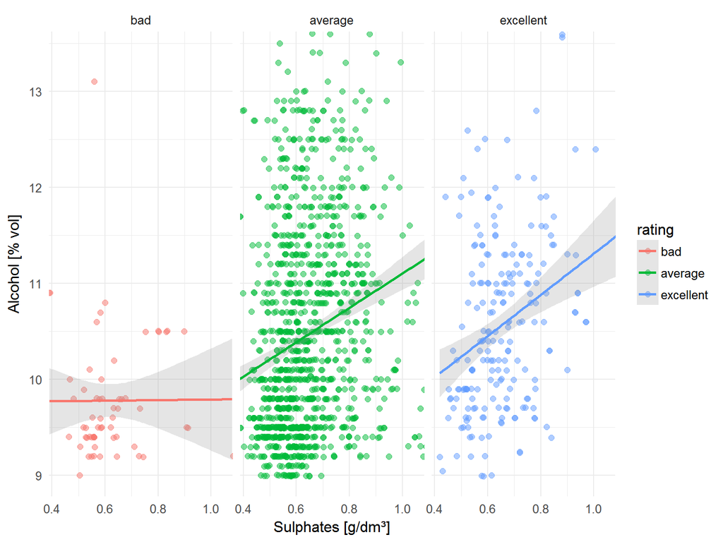

Relationship between *sulphates* and *alcohol*:

- Compared to others the excellent wines tend to have more sulphates and more alcohol volume.
- Most of the bad wines are located in the left-bottom corner.
- The average wines have all kinds of sulphates and alcohol values. But the darker areas are also in the left-bottom corner.

### Identify average wines using *sulphates* and *total sulfur dioxide*

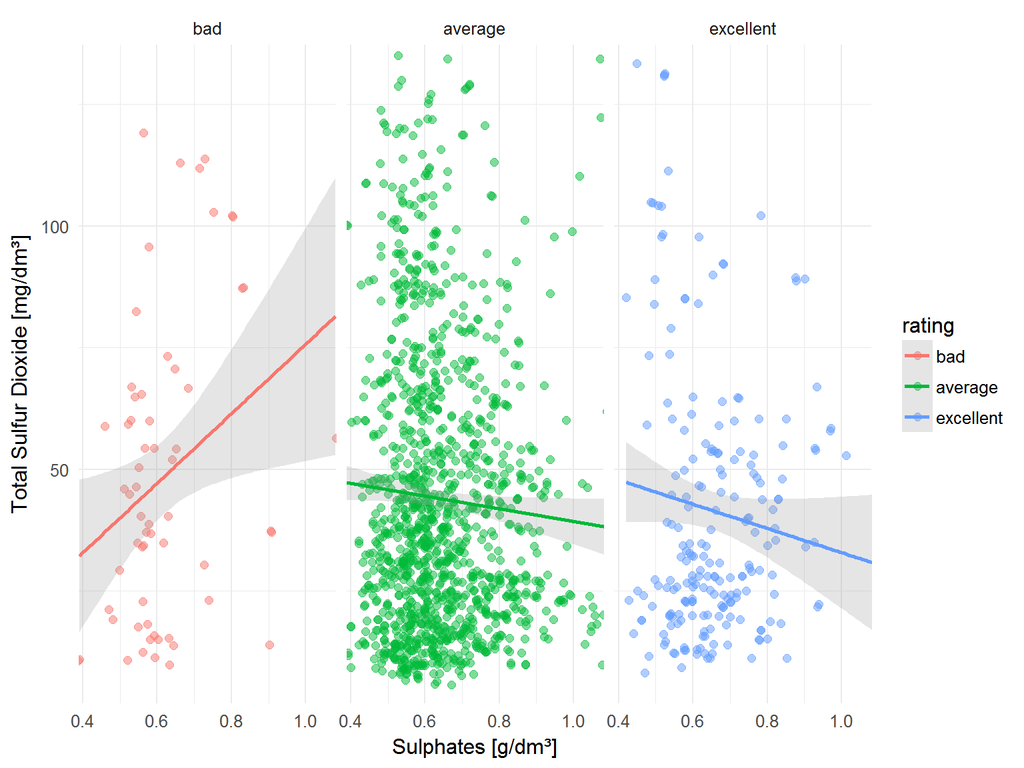

Relationship between *sulphates* and *total sulfur dioxide*:

### Identify bad wines using *sulphates* and *volatile acidity*

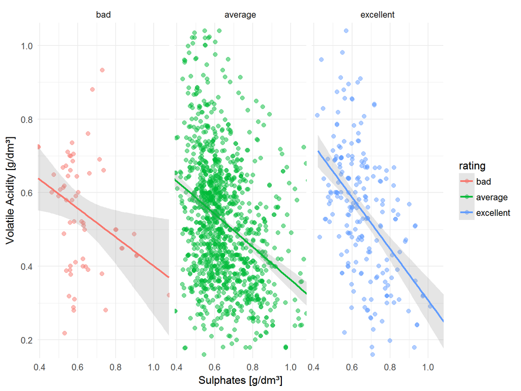

Relationship between *sulphates* and *volatile acidity*:

### Relationship between *volatile acidity* and *alcohol*

Before continue let’s check relationship between *alcohol* and *volatile acidity*:

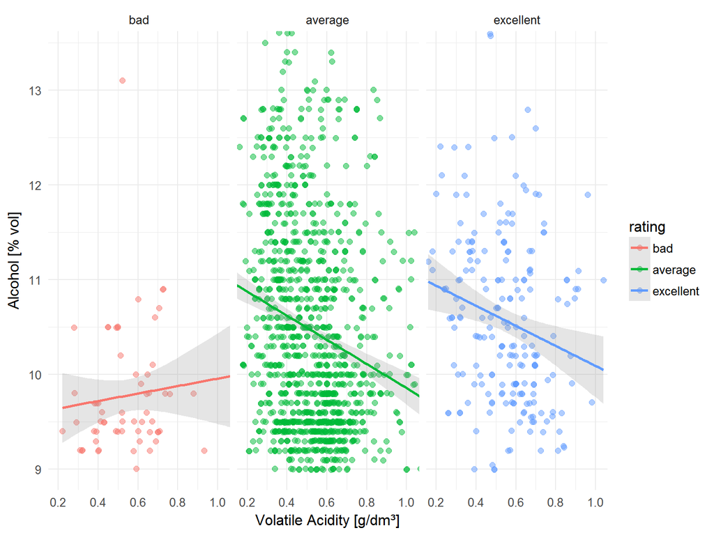

- It appears that most of the bad wines have an alcohol volume below 10 and a volatile acidity below 0.75.
- The values of average wines are widely distributed. Most of them have lower alcohol volume than excellent wines.
- Excellent wines have higher alcohol rates.
- When the volatile acidity is greater than 0.75 the wine has more chance to be average or excellent.

### Create linear regression model

Until now, we have found five major variables from the previous analysis: *alcohol*, *volatile acidity*, *sulphates*, *total sulfur dioxide* and *chlorides*. Now we’ll try to build a prediction model using linear regression and compare our result with the automatic variable selection using the MASS package.

```
##
## Call:
## lm(formula = quality ~ alcohol + volatile.acidity + sulphates +
##     total.sulfur.dioxide + chlorides, data = df)
##
## Residuals:
##      Min       1Q   Median       3Q      Max
## -2.78218 -0.37602 -0.04921  0.43512  1.99891
##
## Coefficients:
##                       Estimate Std. Error t value Pr(>|t|)
## (Intercept)           2.790992   0.220491  12.658  < 2e-16 ***
## alcohol               0.264699   0.017019  15.553  < 2e-16 ***
## volatile.acidity     -1.055563   0.101624 -10.387  < 2e-16 ***
## sulphates             1.378414   0.139985   9.847  < 2e-16 ***
## total.sulfur.dioxide -0.002531   0.000585  -4.326 1.62e-05 ***
## chlorides            -1.578201   0.615073  -2.566   0.0104 *
## ---
## Signif. codes:  0 '***' 0.001 '**' 0.01 '*' 0.05 '.' 0.1 ' ' 1
##
## Residual standard error: 0.6503 on 1509 degrees of freedom
## Multiple R-squared:  0.3634, Adjusted R-squared:  0.3613
## F-statistic: 172.3 on 5 and 1509 DF,  p-value: < 2.2e-16
```

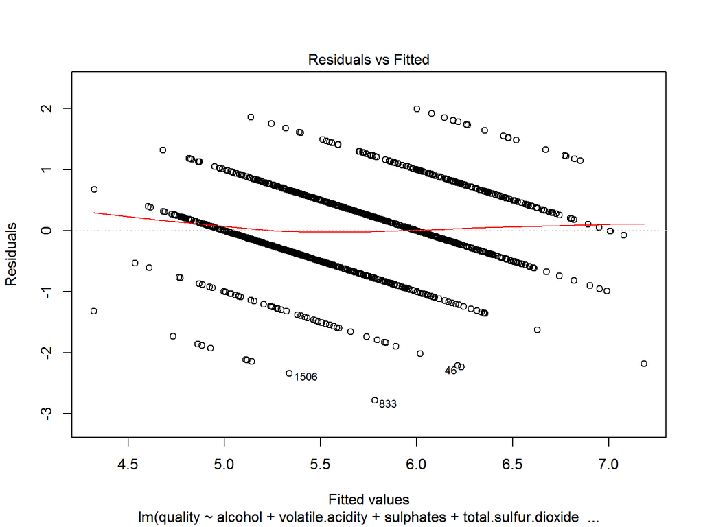

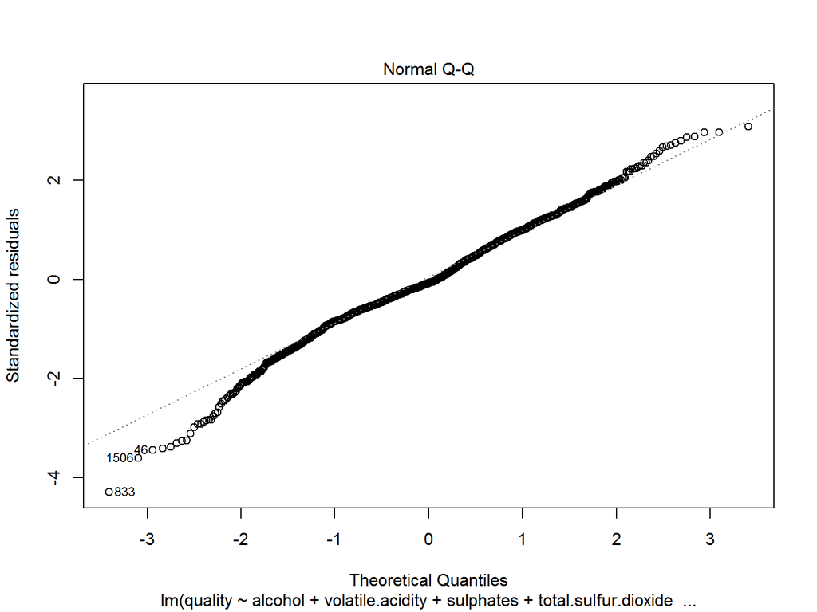

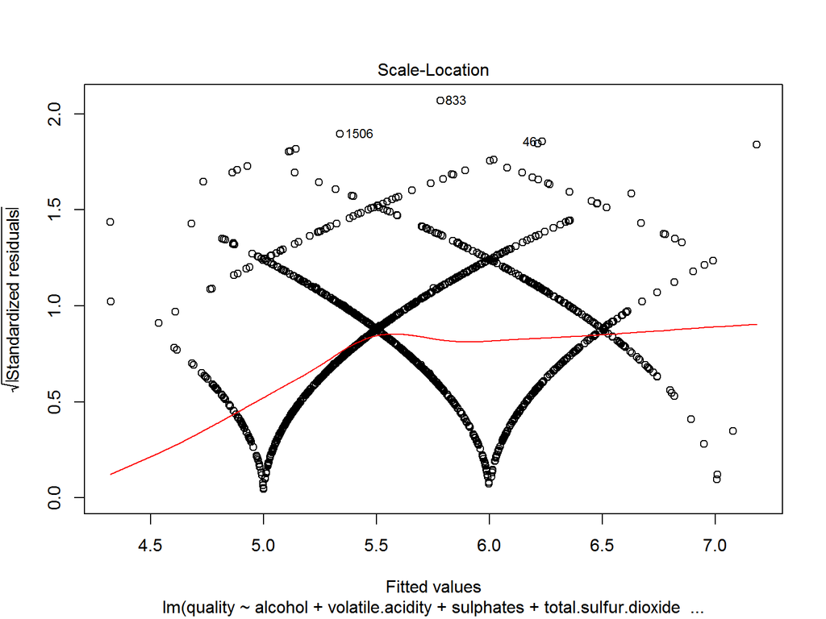

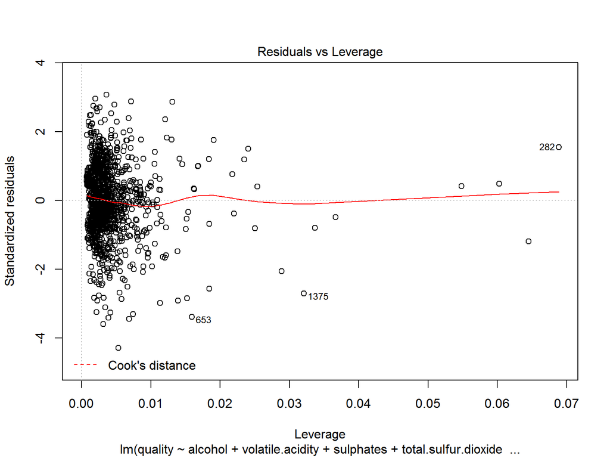

The plot above shows the linear model using our own manual selected variables. The estimates for the coefficients are:

```
## Stepwise Model Path
## Analysis of Deviance Table
##
## Initial Model:
## quality ~ alcohol + volatile.acidity + sulphates + total.sulfur.dioxide +
##     chlorides + density + citric.acid + fixed.acidity + pH +
##     total.sulfur.dioxide + free.sulfur.dioxide + residual.sugar
##
## Final Model:
## quality ~ alcohol + volatile.acidity + sulphates + total.sulfur.dioxide +
##     chlorides + citric.acid + pH
##
##
##                    Step Df   Deviance Resid. Df Resid. Dev       AIC
## 1                                          1503   627.3169 -1311.804
## 2             - density  1 0.01696892      1504   627.3338 -1313.763
## 3      - residual.sugar  1 0.08945551      1505   627.4233 -1315.547
## 4       - fixed.acidity  1 0.24722108      1506   627.6705 -1316.950
## 5 - free.sulfur.dioxide  1 0.75289105      1507   628.4234 -1317.134
```

```
##
## Call:
## lm(formula = quality ~ alcohol + volatile.acidity + sulphates +
##     total.sulfur.dioxide + chlorides + citric.acid + pH, data = df)
##
## Residuals:
##      Min       1Q   Median       3Q      Max
## -2.67854 -0.37666 -0.03153  0.42799  1.88117
##
## Coefficients:
##                        Estimate Std. Error t value Pr(>|t|)
## (Intercept)           4.8209153  0.4747641  10.154  < 2e-16 ***
## alcohol               0.2874098  0.0175641  16.364  < 2e-16 ***
## volatile.acidity     -1.0615748  0.1192876  -8.899  < 2e-16 ***
## sulphates             1.4384582  0.1404490  10.242  < 2e-16 ***
## total.sulfur.dioxide -0.0023353  0.0005839  -4.000 6.65e-05 ***
## chlorides            -1.8322426  0.6230188  -2.941  0.00332 **
## citric.acid          -0.3133325  0.1249348  -2.508  0.01225 *
## pH                   -0.6651904  0.1378643  -4.825 1.54e-06 ***
## ---
## Signif. codes:  0 '***' 0.001 '**' 0.01 '*' 0.05 '.' 0.1 ' ' 1
##
## Residual standard error: 0.6458 on 1507 degrees of freedom
## Multiple R-squared:  0.3731, Adjusted R-squared:  0.3701
## F-statistic: 128.1 on 7 and 1507 DF,  p-value: < 2.2e-16
```

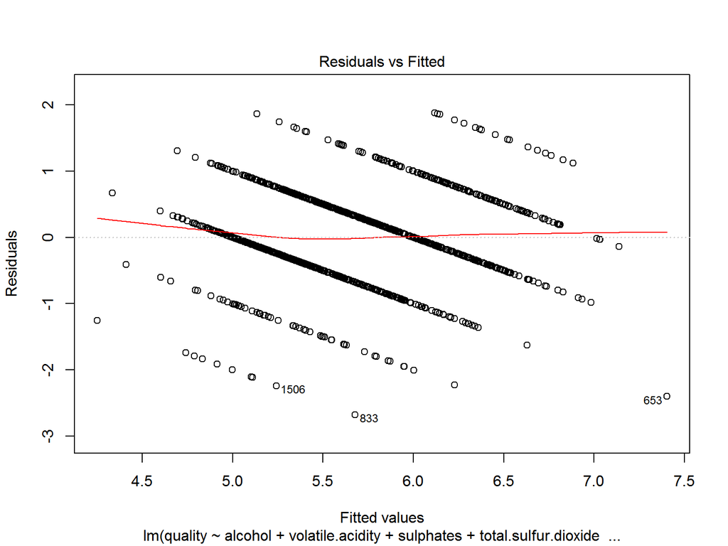

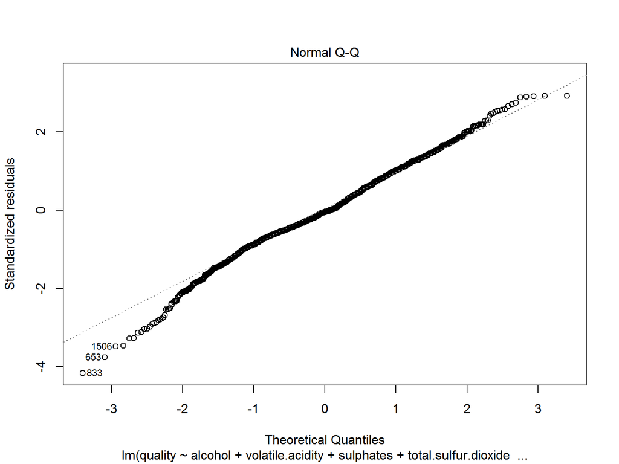

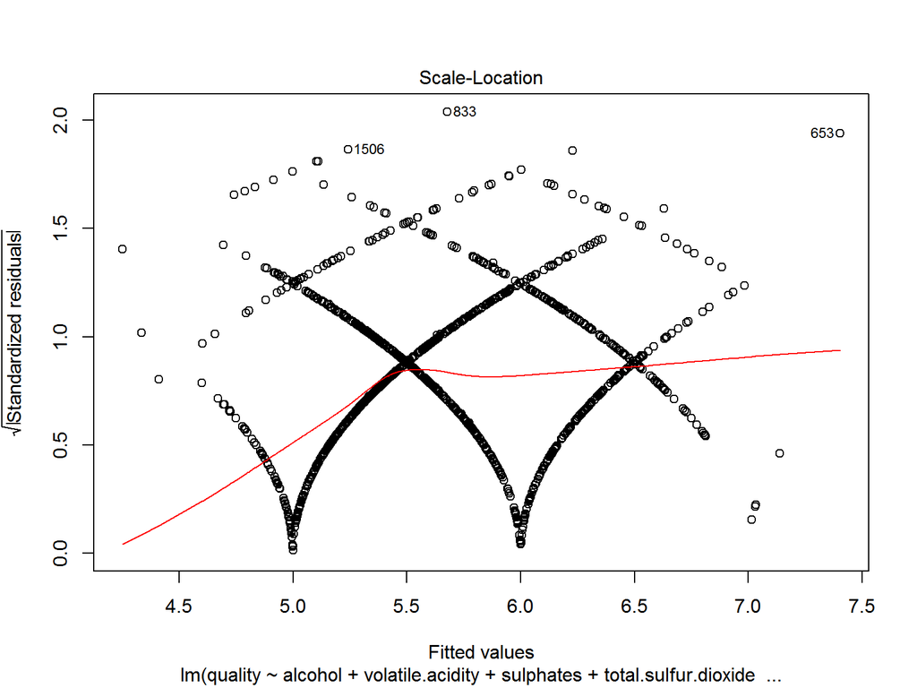

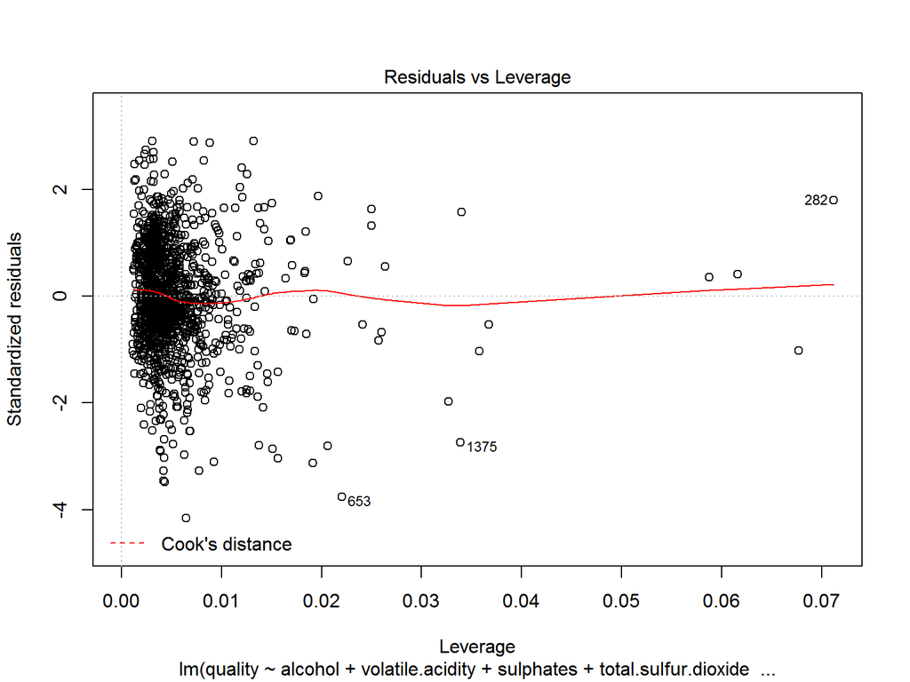

Linear Model using variable selection:

# Multivariate Analysis

### Talk about some of the relationships you observed in this part of the investigation. Were there features that strengthened each other in terms of looking at your feature(s) of interest?

From the faceted scatter plot and the linear regression model we saw that a higher *alcohol*, *sulphates*, and a lower *volatile acidity*, *chlorides* might lead to a better wine quality.

### Were there any interesting or surprising interactions between features?

- In the bivariate analysis we saw only a marginal linear correlation between *pH* and *quality*. Due to the strong correlation between the pH and acid variables I decided to take only *volatile acidity* into the further analysis which had the strongest correlation to *quality*. In the end however, the linear model using variable selection shows that the *pH* variable plays also an important role in indicating good wines.
- In the faceted scatter plots when plotting the main features together, I had expected that the combination of the features would show a more distinctive result. Such as identify bad or excellent wines clearly. However the combination of the variables e.g. using alcohol and volatile acidity had rather a disappointing result. It seems that there were very likely some counteracting effects when combining multiple variables together.

### OPTIONAL: Did you create any models with your dataset? Discuss the strengths and limitations of your model.

Yes. I created one linear model using the selected main features from the previous analysis and another one using stepwise variable selection from the MASS package.

The strengths of the linear model are:

- The linear model is easy to implement and widely used.
- It shows trends and can even predict outputs beyond the observed data set. (e.g. estimates variables for very excellent qualities 9 or 10)

The limitations of the linear model are:

- Linear model tries to describe a linear relationship between the variables. It’s not sure if the dependency between quality and other main features are really linear.
- The quality ratings in the data set were all between 3 to 8. And we had relatively few data for very bad or very excellent wines. It’s questionable if the data used was sufficient to determine the linear model coefficients.
- Linear regression is limited to predict numeric variables.
- Linear regressions are sensitive to outliers.

# Final Plots and Summary

### Plot One: Effect of Alcohol on Quality

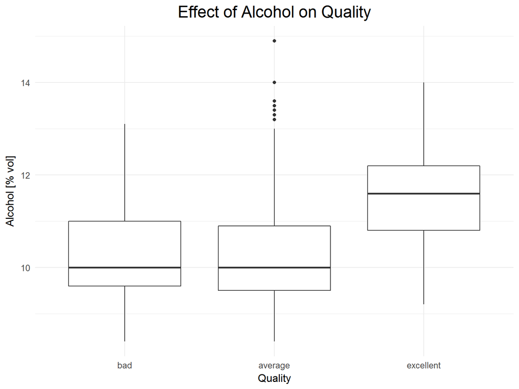

### Description One: Effect of Alcohol on Quality

This first plot I chose is a side-by-side **boxplot** showing the relationship between *quality* and *alcohol*. I think it’s interesting because *alcohol* had the strongest pearson correlation with *quality* and this boxplot shows clearly how the excellent wines tend to have higher *alcohol* volumes than the other two groups.

If we only consider the average and excellent wines, the above plot shows clearly that higher *alcohol* volume yields better wines. The quantiles of bad and average, however, overlap each other somehow. Maybe if we can use some other factors to distinguish between those wines.

Consequently the next time when I go to the wine shop I’ll check for wines with a higher alcohol volume.

### Plot Two: Combined Effect of Alcohol and Volatile Acidity on Quality

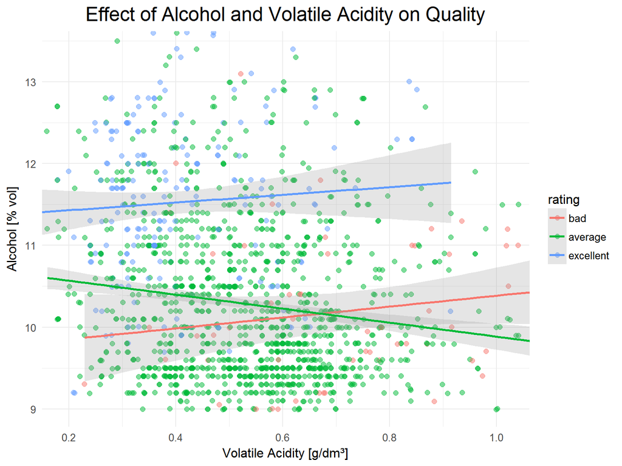

### Description Two

In the second plot we demonstrate how the *alcohol* and *volatile acidity* affect the *quality* in a combined way. This plot is interesting because it displays the individual data points for the *alcohol* and *volatile acidity* values and uses different colors to show the three *quality* levels

The plot above shows that blue dots representing wines with excellent qualities tend to concentrate in the left upper corner. This means that excellent wines have lower *volatile acidity* and higher *alcohol* The bad wines in other hand tend to be have higher *volatile acidity* and lower *alcohol* volume.

Additionally in this plot we see that there are far more wines with average rating than the other two groups. And the average wines seem largely overlaps with both excellent and bad wines in both variables. But if we can be selective, with an alcohol volume higher than 11.5% and a volatile acidity below 0.4g/dm³ we’ll hardly ever encounter bad wines and have even more than 50% chance to get an excellent bottle.

### Plot Three: Linear Regression Model

```
##
## Call:
## lm(formula = quality ~ alcohol + volatile.acidity + sulphates +
##     pH + chlorides + citric.acid, data = df)
##
## Residuals:
##      Min       1Q   Median       3Q      Max
## -2.68019 -0.37114 -0.05151  0.44948  1.93938
##
## Coefficients:
##                  Estimate Std. Error t value Pr(>|t|)
## (Intercept)       4.69674    0.47610   9.865  < 2e-16 ***
## alcohol           0.30347    0.01718  17.660  < 2e-16 ***
## volatile.acidity -1.09592    0.11957  -9.166  < 2e-16 ***
## sulphates         1.43721    0.14115  10.182  < 2e-16 ***
## pH               -0.70271    0.13823  -5.084 4.16e-07 ***
## chlorides        -1.70660    0.62531  -2.729  0.00642 **
## citric.acid      -0.36207    0.12496  -2.898  0.00382 **
## ---
## Signif. codes:  0 '***' 0.001 '**' 0.01 '*' 0.05 '.' 0.1 ' ' 1
##
## Residual standard error: 0.649 on 1508 degrees of freedom
## Multiple R-squared:  0.3664, Adjusted R-squared:  0.3639
## F-statistic: 145.3 on 6 and 1508 DF,  p-value: < 2.2e-16
```

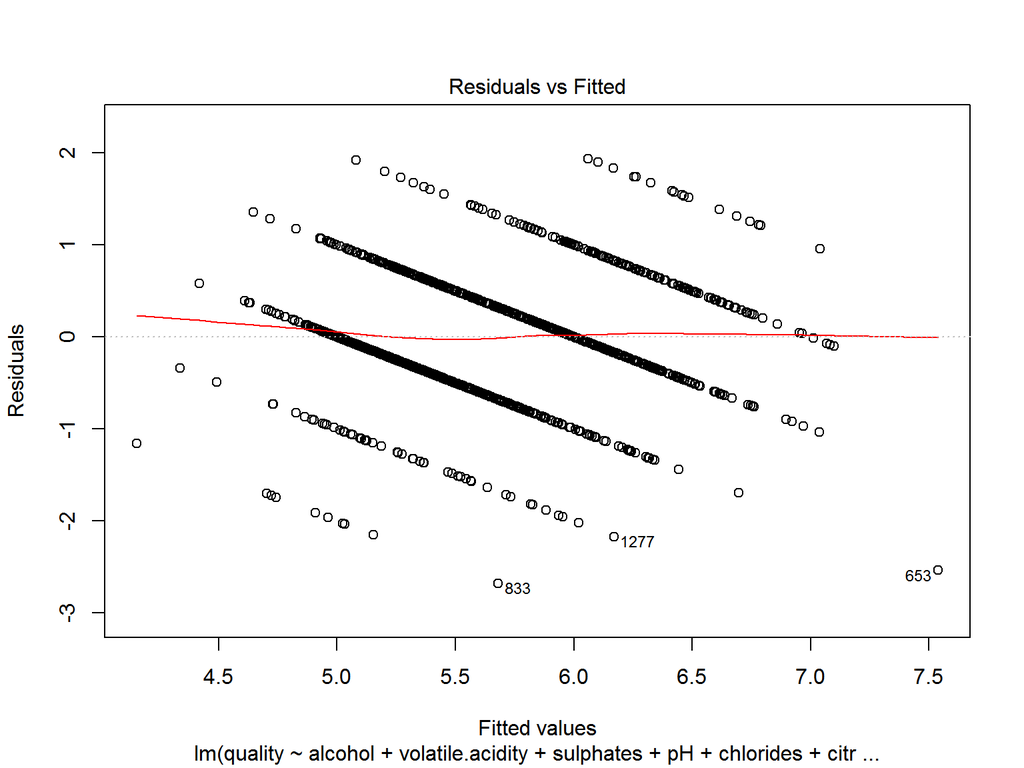

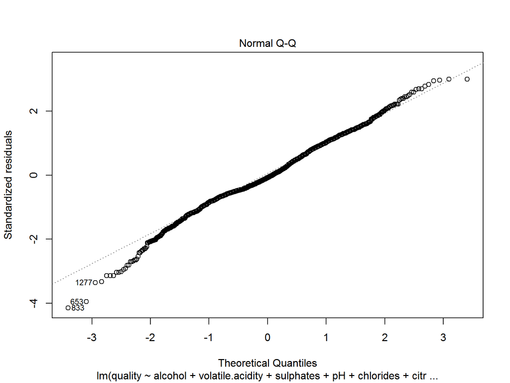

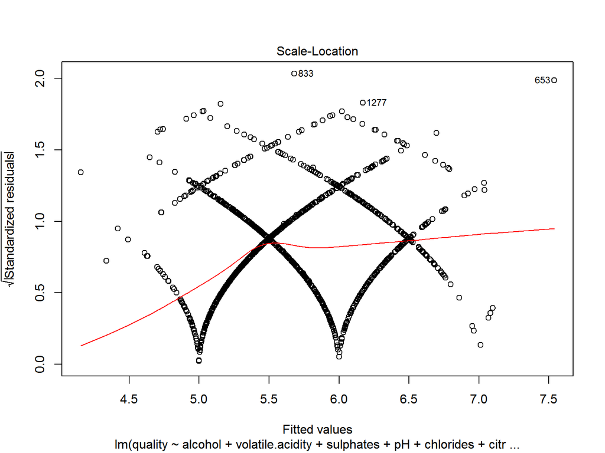

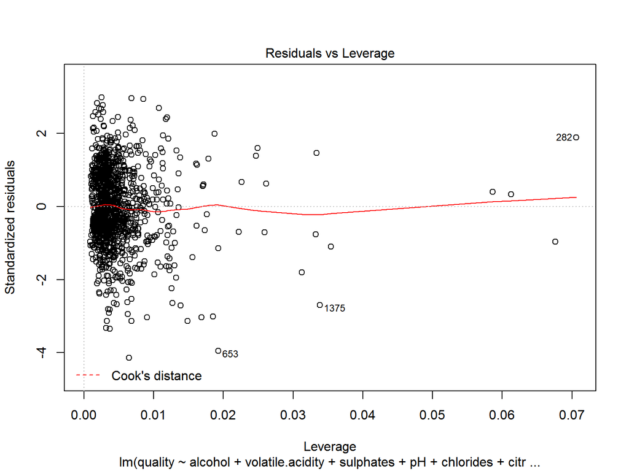

### Description Three: Linear Regression Model

This final plot is perhaps one of the most interesting visualization as it illustrates the relationship between quality and the independent features as a linear model. In the linear model above we used the results from the multivariate analysis and uses the following coefficients:

- alcohol: 0.3
- volatile.acidity: -1.1
- sulphates: 1.4
- chlorides: -1.7
- pH: -0.7
- citric.acid: -0.4
- (intercept): 4.7

The normal QQ-plot compares the quantiles of the standardized residuals to the theoretical quantiles of the linear model. The points follow a mainly linear pattern, suggesting that the data are nearly identical distributed. But in the both ends there are a recognizable amount of points deviating from the theoretical quantiles.

From the lm() output we know that the residual standard error of this model is 0.649 on 1508 degrees of freedom and and adjusted R² of 0.364 which says that the linear model fits the data only moderately.

As we discussed in the last optional question, the relationships between the variables of the underlying data might be actually unlinear. It is subject for a further analysis. As I answered that question, another model came up in my mind. I thought about rule-based models maybe the random forest model.

# Reflection

In this exercise, we explored the red wine data set on its quality and other physicochemical properties using exploratory data analysis. We have discovered interesting relationships in the data step by step and produced and refines several plots to illustrate them.

It was amazing to see that the alcohol volume had a such big influence on identifying excellent wines which was clearly see in the side-by-side boxplot.

But there were difficulties too during the analysis. In the data visualization phase some struggles happened when plotting with some external libraries which had other behaviors than *ggplot2*, such as *cdplot* or *corrplot*. I had troubles to finetune their colors or font sizes.For example, when I wanted to add the title for the *corrplot*, only the bottom half of it was displayed in the plot. The feature to merge them into a matrix like using *grid.arrange* was missing as well.

In the bivariate and multivariate analysis we had problems to differentiate between the bad and average wines. For the future, we might need to dive deeper to investigate in that direction.

Lastly, it should be mentioned that the taste of wine is highly subjective. Different testers might give the same wine different quality ratings. I can even imagine that the same wine could have different ratings by the same tester depending on the day or the mood of the tester. Nevertheless, our analysis could uncover some interesting insights of the wine quality in the available observations.

# References

- [knitr output manipulation](http://yihui.name/knitr/demo/output/)
- [ggplot documentation](http://docs.ggplot2.org/current/index.html)
- [cdplot example](https://www.rdocumentation.org/packages/graphics/versions/3.3.2/topics/cdplot)
- [corrplot example](https://cran.r-project.org/web/packages/corrplot/vignettes/corrplot-intro.html)
- [UCLA: robust regression](http://stats.idre.ucla.edu/r/dae/robust-regression/)
- [Wikipedia: qq plot](https://en.wikipedia.org/wiki/Q%E2%80%93Q_plot)
- [Wikipedia: linear regression](https://en.wikipedia.org/wiki/Linear_regression)
- [Udacity Website](https://www.udacity.com/)